# Intro and Load Streamflow

L. Patterson and J. Fay

Spring, 2018

# Goal for today

- Learn how to use R for streamflow data
- Learn how to load data from NWIS
- Learn how to explore and visualize data
- Learn how to analyze streamflow data

## **Many roads lead to Rome - learning how to find those roads and what works best for you is key**

# R Resources

Free online course to learn R, Python, Excel, etc.

- https://www.datacamp.com/
- https://www.codecademy.com/
- https://www.lynda.com/ (free through Duke)
- Jenny Bryans UBC Cource on Stats in R: http://stat545.com/topics

Learning how to problem solve in the moment:

- Google question and inclue “Rcran” in search term
- Stack Overflow: https://stackoverflow.com/
- R bloggers: https://www.r-bloggers.com/
- rseek.org (Google, but focused on R)
- Quick R - statmethods.net

Within R:

- `help(functionName)` or `?functionName`
- `??topic` to do a broad search of a topic
- `vignette("topic")`
- `appropos("topic")`

Useful shortcuts in R

- `<-`: `Alt` + `-`
- `<%<`: `Shift` + `Ctrl` + `M`
- For a cheat sheet with *most* shortcuts: `alt` + `shift` + `K`

# RStudio

RStudio is a useful interface to using R. When you open R Studio you will notice a menu up top and typically 4 windows that you can reorganize in Tools –> Global Options.

[figure not shown]

Rstudio

# Background: How has Falls Lake affected streamflow?

Prior to 1978, flooding of the Neuse River caused extensive damage to public and private properties including roadways, railroads, industrial sites, and farmlands. The Falls Lake Project was developed by the U.S. Army Corps of Engineers to control damaging floods and to supply a source of water for surrounding communities. Construction of the dam began in 1978 and was completed in 1981. In addition to recreation opportunities, Falls Lake now provides flood control, water supply, water quality, and fish and wildlife conservation resources (https://111.ncparks.gov/falls-lake-state-recreation-area/history).

# Analytical workflow: A Preview

Data analysis projects follow a similar workflow, one that begins with a general question or objective that guides our process of turning data into actionable information. Let’s begin by examining our workflow, depicted in the diagram below.

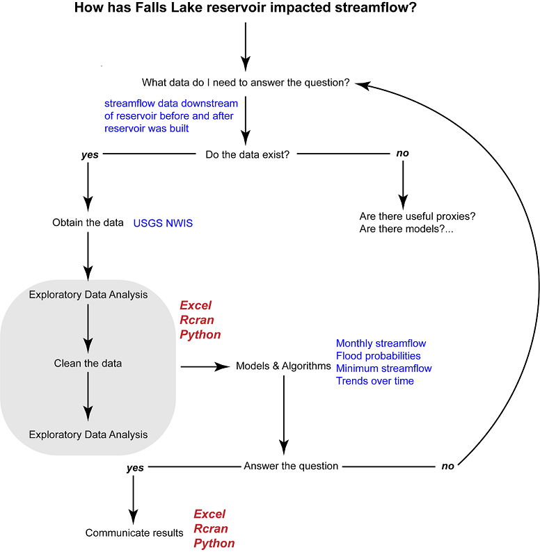

Analytic Workflow

# Applying the Analytical Workflow: Falls Lake

## Obtaining the data

The USGS actively supports Rcran development by building a community of practice. This community has developed several R packages that can be used to load and analyze streamflow data: https://owi.usgs.gov/R/packages.html

The package we will be using to load data into R is the dataRetrieval library. Information on how to use this library can be found here: https://owi.usgs.gov/R/dataRetrieval.html#2

## Installing packages and loading libraries

Rcran is open source, meaning anyone can create packages for other people to use. To access these packages you must first install them onto your machine. Installing packages only needs to be done on one occasion; however, you may decide to install packages every time you open your script if you think the package is being regularly updated.

There are 2 primary ways to install a package onto your machine.

**Method 1** - Manual

1. In the `menu` click on `Tools` then `Install Packages`.
2. Select the package(s) you wish to install. Start typing and it will provide options.

**Method 2** - Code

`install.packages("XXX")`

You can install multiple packages by typing: `install.packages(c("XXX1","XXX2","XXX3"))`

The `c()` creates a list that r can read through.

For this project we will load in the following libraries:

- `dataRetrieval` - USGS package to download data directly to R
- `EGRET` - USGS package that contains some basic statistics for streamflow data
- `ggplot2` - popular plotting library in R
- `dplyr and magrittr` are used to link commands together by piping. Pipes, `%>%` link each call made in R to the previous call. We’ll learn more on this later.
- `lubridate` - package used for dates and time
- `leaflet` - package used for maps

In the case of the USGS `dataRetrieval` package, the package is under active development. In this case you may want to reinstall the package each time you use it to make sure you have all the latest functionality.

Libraries are now installed on your screen, but they aren’t loaded into your current session. You have to tell R to load the library for use using `library(XXX)`.

### Prep the workspace by installing (if needed) and loading libraries

```r
#install.packages("dataRetrieval", repos=c("http://owi.usgs.gov/R", getOption("repos")))
library(dataRetrieval)
library(EGRET)
library (ggplot2)

#library for pipes
library(dplyr)
library(magrittr)

#used for dates
library(lubridate)

#used for mapping
library(leaflet)
#access vignette if needed
#vignette("dataRetrieval", package="dataRetrieval")
```

## Download data directly from NWIS

We will use the USGS packages to download data directly from the USGS. To do this we need to identify what we want to download.

*https://waterdata.usgs.gov/nwis/dv?cb_00060=on&format=rdb&site_no=02087500&referred_module=sw.=&begin_date=1930-10-01&end_date=2017-09-30*

We need to define:

- `siteNumbers` - this is the USGS gauge containing the data we want to download
  - We will define the variable siteNo and assign it to Clayton gauge: `02087500`
    - `siteNo <- '02087500'`
- `parametercd` - this is the parameter code… what we want to download from the gauge.
  - Parameter codes can be found here: https://help.waterdata.usgs.gov/code/parameter_cd_query?fmt=rdb&inline=true&group_cd=%
  - We will define the variable `pcode` and set it equal to `'00060'` which is the code for discharge.
    - `pcode = '00060'`
- `statCd` is the statistical code for daily values. We are interested in the mean.
  - Statistical codes can be found here: https://help.waterdata.usgs.gov/code/stat_cd_nm_query?stat_nm_cd=%25&fmt=html
  - We will define the variable `scode` and set it equal to `'00003'`
    - `scode = '00003'`
- We also can identify the start and the end date. In this case we will define the following:
  - `start.date = "1930-10-01"`
  - `end.date = "2017-09-30"`

#### Identify parameters

```r
#Identify gauge to download
siteNo <- '02087500' #Clayton, don't forget to add the zero if it is missing
#siteNo <- '02089000' #Goldsboro, don't forget to add the zero if it is missing

#Identify parameter of interest: https://help.waterdata.usgs.gov/code/parameter_cd_query?fmt=rdb&inline=true&group_cd=%
pcode = '00060' #discharge (cfs)

#Identify statistic code for daily values: https://help.waterdata.usgs.gov/code/stat_cd_nm_query?stat_nm_cd=%25&fmt=html
scode = "00003"  #mean

#Identify start and end dates
start.date = "1930-10-01"
end.date = "2017-09-30"

#pick service
serv <- "dv"
```

- We can now put all this information to call the data from the USGS NWIS website. There are a couple of ways we can do this, but we will focus on the following: `readNWISdv`.
  - We will put the data into the variable `neuse`.
- The dataRetreivalpackage has an additional commands
  - `neuse <- renameNWISColumns(neuse)` provides meaningful column names to the data
    - You can see what the column names are by: `colnames(neuse)`
  - You can access different attributes associated with this stream gauge. To know what that list is:
    - `names(attributes(neuse))`
  - From that list you can look at:
    - `parameterInfo <- attr(neuse, "variableInfo")` provides information on variables
    - `siteInfo <- attr(neuse, "siteInfo")`

```r
#Load in data using the site ID
neuse <- readNWISdata(siteNumbers = siteNo, parameterCd = pcode, statCd = scode, startDate=start.date, endDate=end.date, service = serv)
  summary(neuse); dim(neuse)
```

```
##   agency_cd           site_no             dateTime
##  Length:31777       Length:31777       Min.   :1930-10-01
##  Class :character   Class :character   1st Qu.:1952-07-01
##  Mode  :character   Mode  :character   Median :1974-04-01
##                                        Mean   :1974-04-01
##                                        3rd Qu.:1995-12-31
##                                        Max.   :2017-09-30
##  X_00060_00003   X_00060_00003_cd      tz_cd
##  Min.   :   45   Length:31777       Length:31777
##  1st Qu.:  301   Class :character   Class :character
##  Median :  525   Mode  :character   Mode  :character
##  Mean   : 1111
##  3rd Qu.: 1200
##  Max.   :22500
```

```
## [1] 31777     6
```

```r
#OR You can use basic web retrievals (just remove the service call)
  #readNWISuv = unit data;            readNWISdv = daily data;            readNWISgwl = groundwater level
  #readNWISmeas = surface water;      readNWISpeak = peakflow;            readNWISqw = water quality
  #readNWISrating = rating curves;    readNWISpCode = parameter code      readNWISsite = Site data
  neuse <- readNWISdv(siteNumbers = siteNo, parameterCd = pcode, statCd = scode, startDate=start.date, endDate=end.date)

#rename columns to something more useful
  neuse <- renameNWISColumns(neuse); colnames(neuse)
```

```
## [1] "agency_cd" "site_no"   "Date"      "Flow"      "Flow_cd"
```

```r
#see attributes
#attributes(neuse)
#to access attributes in future: attr(neuse, "name of interest)
names(attributes(neuse))
```

```
## [1] "names"         "row.names"     "url"           "siteInfo"
## [5] "variableInfo"  "disclaimer"    "statisticInfo" "queryTime"
## [9] "class"
```

```r
  parameterInfo = attr(neuse, "variableInfo")
  siteInfo <- attr(neuse, "siteInfo")
```

# Exercise 1: Load streamflow data for the Neuse River near Goldsboro, NC

1. Find the site number for Goldsboro, NC
2. Load the data into variable `goldsboro’
3. Rename columns

## Exploratory Data Analysis: Plot data

Now that we have our data, we should explore and inspect the data before we dive into our analysis. This may expose irregularities in the data, stemming either from our import process or in the dataset itself. Plots and summary statistics are a quick way to reveal any data gaps or outliers.

- First, compute cms values from your cfs ones:
  - Create a new column use `$`

```r
#Create cms column to plot cubic meters per second
neuse$Flow_cms <- neuse$Flow*0.028316847
  summary(neuse$Flow_cms)
```

```
##    Min. 1st Qu.  Median    Mean 3rd Qu.    Max.
##   1.274   8.523  14.870  31.460  33.980 637.100
```

#### Plot streamflow data to look for gaps/outliers

- Basic Plots in R:
  - Create the margins of your plot using `par`
  - `par(mar) = c(3,5,2,5))` where the margin is set for (bottom, left, top, right)
- Plot the data… there are a lot of additions you can add to the plot with a `,`
  - Basic plot: `plot(xaxis, yaxis)`, so in this case: `plot(neuse$Date, neuse$Flow_cms)`
  - `type` tells the plot what type of plot you want. `n` tells the plot not to show points
  - `yaxt` and `xaxt` tell the plot what to do with the y and x axis
  - `ylim` and `xlim` tell the plot the min and max of the respective axes
  - `ylab` and `xlab` set the labels for the respective axes. `main` sets the title for the plot.
- Currently, the plot is empty. The following commands fill the plot.
  - `axis` lets you set up with more control the axis of interest. `1` is the x-axis. `2` is the y-axis.
  - `points()` and `lines()` allow you to overlay data onto the plot as points or lines. Because there are so many points we want to plot the data as lines. There are many ways to stylize points and lines.
  - `col` sets the color, `lwd` sets the width, `lty` sets the type of line
  - `abline` allows you to draw straight lines in the plot. `v` for vertical lines, `h` for horizontal lines. Here we draw a vertical line around the time falls lake was constructed

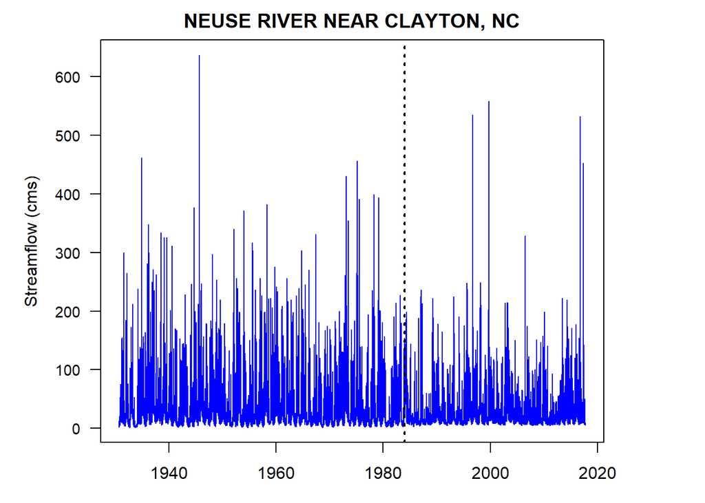

```r
#Basic plot
par(mar = c(3,5,2,5)) #set plot margins
plot(neuse$Date, neuse$Flow_cms, type='n', yaxt="n", xlim=c(min(neuse$Date),max(neuse$Date)),
       ylab="Streamflow (cms)", xlab = '', main=siteInfo$station_nm)
       #yaxs="i", xaxs="i")#gets rid of spaces inside plot
  axis(2, las=2, cex.axis=0.9)
  lines(neuse$Date, neuse$Flow_cms, col="blue", lty=1, lwd=1)
  abline(v=as.Date("1984-01-01"), lty=3, col="black", lwd=2)
```

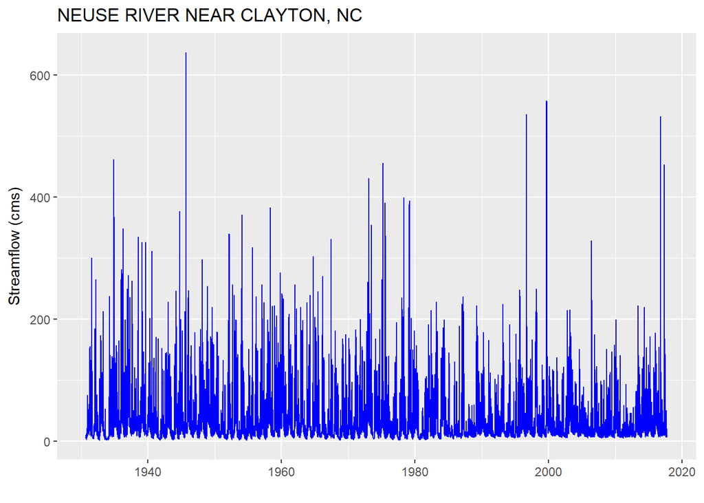

```r
#OR
#you can plot data using ggplot. ggplot is commonly used.
ts <- ggplot(data=neuse, aes(Date,Flow_cms)) +
      geom_line(colour="blue")
#make it prettier
ts <- ts + xlab("") + ylab("Streamflow (cms)") +
      ggtitle(siteInfo$station_nm)
ts
```

# Exercise 2: Plot streamflow for ‘goldsboro’

1. Using either plot or ggplot, plot the streamflow for goldsboro
2. Plot cfs instead of cms and change the label
3. Change the line color to “red”
4. Change the title to reflect the correct gauge

## Exploratory Data Analysis: Summary Statistics

**Know your data**. Whenever you get data, it’s good practice to look at and understand the raw data to make sure it looks reasonable and you understand something about its quality and content. One of the first things to assess in the metadata is how confident you are in the quality of the data being used in your analysis. Is the data fit for purpose?

*How confident are we in the data?*

- If you noticed in the summary of the data there was a column with confidence codes on the quality of the data.
- `table` creates a table that counts the number of occurrences for each category of confidence code.
  - notice the table is in an array. We want to put it into a data frame (similar to the neuse data) so we can manipulate the columns. The command `as.data.frame` puts the table into a format we can use.
- `colnames` allows you to rename the columns.
- To perform operations on the data you must call the column name. You do this by first listing the name of your data: confidence and then calling on the column of interest by using `$` and then the column name.
- You can create a pie chart and set the color of the pie using the following command: `pie()`
  - You are creating the pie chart using the `percent` column and labeling the chart using the `category` column. `cex` refers to the size of the label.

```r
#How confident are we in the data?
total.n <- dim(neuse)[1]; total.n
```

```
## [1] 31777
```

```r
table(neuse$Flow_cd)
```

```
##
##     A   A e
## 31635   142
```

```r
confidence <- as.data.frame(table(neuse$Flow_cd))  #places table into a dataframe
  colnames(confidence)<-c("Category","Number")     #creates meaningful column names
  confidence$Percent <- confidence$Number/total.n*100
      confidence$Percent <- round(confidence$Percent,2)
confidence
```

```
##   Category Number Percent
## 1        A  31635   99.55
## 2      A e    142    0.45
```

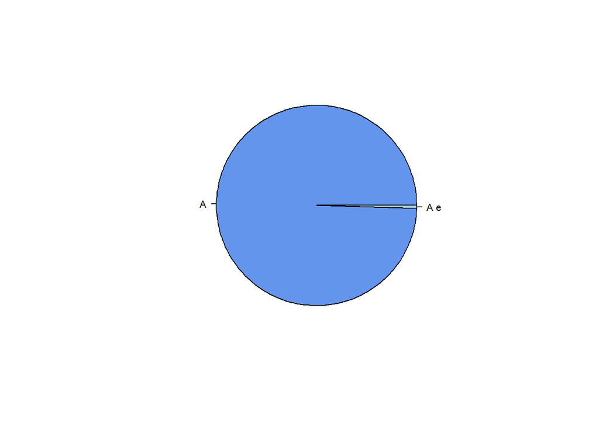

```r
#quick plot if interested
pie(confidence$Percent, labels=confidence$Category, col=c("cornflowerblue","lightblue","darkorange","orange"), cex=0.7)
```

### Using functions

Summary statistics provide another quick way to examine our data for peculiarities. Here, we’ll outline the process for computing min, max, mean, and percentiles from our data. There are many ways to accomplish this task. We will explore 2 methods: functions and piping (dplyr).

**Functions** allow you to program a process you wish to repeat many times. Typically you call on this function to perform some task on some data.

- First we want to create a data frame to store the output from our function once it runs. A data frame is a matrix of rows and columns. Here will create a data frame with 8 rows and 4 columns.
  - We will then give the data frame meaningful column headers using `colnames`
  - And we will fill in the first column of data with the names of the statistics we wish to run. *Next, we will write our function. The form of a function is: `function name = function(parameter1, parameter2, ...) {the tasks to perform}`

```r
#create data frame
sum.stats <- as.data.frame(matrix(nrow=8, ncol=4))
  colnames(sum.stats) <- c("Statistics","p1930-2017","p1930-1979","p1984-2017")
#Fill in first column
  sum.stats$Statistics <- c("Min","10th percentile","25th percentile","Median","Mean","75th percentile", "90th percentile","Max")

#Function to fill in second column
  # Our function has 2 parameters. The first parameter is the data we want to go into the function. The second is the column we want to fill in our data frame.
gen_stats = function(data, column.no){
  #Now we perform the task. We want to fill the sum.stats dataframe. To do this we run a stat and place that value into a specific row and column.
  #data.frame[row number, column number]
  sum.stats[1,column.no] <- min(data$Flow_cms);
  sum.stats[2,column.no] <- quantile(data$Flow_cms, 0.10);    sum.stats[3,column.no] <- quantile(data$Flow_cms, 0.25);
  sum.stats[4,column.no] <- median(data$Flow_cms);            sum.stats[5,column.no] <- mean(data$Flow_cms);
  sum.stats[6,column.no] <- quantile(data$Flow_cms, 0.75);    sum.stats[7,column.no] <- quantile(data$Flow_cms, 0.90);
  sum.stats[8,column.no] <- max(data$Flow_cms);

  #we return the dataframe. This gives us access to the data frame outside of the function
  return(sum.stats)
}
#call the function to run using the following parameters
sum.stats <- gen_stats(neuse, 2)
sum.stats$`p1930-2017` <- round(sum.stats$`p1930-2017`,3)  #round data to look pretty
sum.stats #make sure numbers look right
```

```
##        Statistics p1930-2017 p1930-1979 p1984-2017
## 1             Min      1.274         NA         NA
## 2 10th percentile      5.890         NA         NA
## 3 25th percentile      8.523         NA         NA
## 4          Median     14.866         NA         NA
## 5            Mean     31.460         NA         NA
## 6 75th percentile     33.980         NA         NA
## 7 90th percentile     83.252         NA         NA
## 8             Max    637.129         NA         NA
```

```r
#Now we can subset the data and rerun function before and after Falls Lake
neuse.pre1980 <- subset(neuse, Date<="1979-12-31");          summary(neuse.pre1980$Date)
```

```
##         Min.      1st Qu.       Median         Mean      3rd Qu.
## "1930-10-01" "1943-01-23" "1955-05-17" "1955-05-17" "1967-09-08"
##         Max.
## "1979-12-31"
```

```r
neuse.post1984 <- subset(neuse, Date>="1984-01-01");         summary(neuse.post1984$Date)
```

```
##         Min.      1st Qu.       Median         Mean      3rd Qu.
## "1984-01-01" "1992-06-08" "2000-11-15" "2000-11-15" "2009-04-23"
##         Max.
## "2017-09-30"
```

```r
#call the function to calculate summary statistics
sum.stats <- gen_stats(neuse.pre1980,3)
sum.stats <- gen_stats(neuse.post1984,4)

#round values
sum.stats[,c(2:4)]<- round(sum.stats[,c(2:4)],3)
  sum.stats
```

```
##        Statistics p1930-2017 p1930-1979 p1984-2017
## 1             Min      1.274      1.274      2.973
## 2 10th percentile      5.890      4.955      7.249
## 3 25th percentile      8.523      8.523      8.750
## 4          Median     14.866     16.452     13.309
## 5            Mean     31.460     33.085     29.432
## 6 75th percentile     33.980     34.263     32.848
## 7 90th percentile     83.252     84.384     81.553
## 8             Max    637.129    637.129    557.842
```

# Exercise 3: Use gen_stats to compute stats for ‘goldsboro’

1. Create a dataframe called ‘gold.stats’ and change the number of columns to 5
2. Call the `gen_stats` function with different parameters and save the results into your new dataframe.
3. Repeat for 1930-1979, 1980-1983, and 1984-2017

### Using `dplyr` and `pipes`. Pipes create a chain of commands building on the previous command.

**dplyr and pipes**. Pipes create a chain of commands that build on the previous command. There are two libraries you need to do this: `dplyr` and `magrittr`. The symbol `%>%` is the pipe that connects a chain of commands together. The `%>%` is like saying `and then`.

- In this example we will create a new data frame, `sum.stats2` to hold the summary statistics. We will then perform a series of commands on the `neuse` data. Essentially we are saying to grab the `neuse` data and then calculate the following variables in the `sum.stats2` frame.
- Repeat the commands while subsetting the data to different time periods using the `filter()` command.

```r
#create data frame
sum.stats2 <- as.data.frame(matrix(nrow=8, ncol=4))
colnames(sum.stats2) <- c("Statistics","p1930-2017","p1930-1980","p1984-2017")

#Fill in first column
sum.stats2$Statistics <- c("Min","p10","p25","Median","Mean","p75", "p90","Max")

sum.stats2 <- neuse %>%
    summarize(min = min(Flow_cms, na.rm=TRUE),
              p10 = quantile(Flow_cms, 0.10, na.rm=TRUE),
              p25 = quantile(Flow_cms, 0.25, na.rm=TRUE),
              median = median(Flow_cms, na.rm=TRUE),
              mean = mean(Flow_cms, na.rm=TRUE),
              p75 = quantile(Flow_cms, 0.75, na.rm=TRUE),
              p90 = quantile(Flow_cms, 0.90, na.rm=TRUE),
              max = max(Flow_cms, na.rm=TRUE)
              )
sum.stats2 <- as.data.frame(sum.stats2)

#repeat for the other time periods. Use the 'filter' command:
sum.stats2[2,] <- neuse %>%
  filter(Date<="1979-12-31") %>%
  summarize(min = min(Flow_cms, na.rm=TRUE),
            p10 = quantile(Flow_cms, 0.10, na.rm=TRUE),
            p25 = quantile(Flow_cms, 0.25, na.rm=TRUE),
            median = median(Flow_cms, na.rm=TRUE),
            mean = mean(Flow_cms, na.rm=TRUE),
            p75 = quantile(Flow_cms, 0.75, na.rm=TRUE),
            p90 = quantile(Flow_cms, 0.90, na.rm=TRUE),
            max = max(Flow_cms, na.rm=TRUE)
  )

sum.stats2[3,] <- neuse %>%
  filter(Date>="1984-01-01") %>%
  summarize(min = min(Flow_cms, na.rm=TRUE),
            p10 = quantile(Flow_cms, 0.10, na.rm=TRUE),
            p25 = quantile(Flow_cms, 0.25, na.rm=TRUE),
            median = median(Flow_cms, na.rm=TRUE),
            mean = mean(Flow_cms, na.rm=TRUE),
            p75 = quantile(Flow_cms, 0.75, na.rm=TRUE),
            p90 = quantile(Flow_cms, 0.90, na.rm=TRUE),
            max = max(Flow_cms, na.rm=TRUE)
  )

#reshape and round tables
final.stats <- as.data.frame(t(round(sum.stats2,3)));   #t transposes the matrix
  final.stats$Statistics <- row.names(final.stats);     #cahnge rownames to columns
final.stats <- final.stats[,c(4,1,2,3)];      #reorder data frame
colnames(final.stats) <- c("Statistics","p1930-2017","p1930-1980","p1984-2017")
  final.stats
```

```
##        Statistics p1930-2017 p1930-1980 p1984-2017
## min           min      1.274      1.274      2.973
## p10           p10      5.890      4.955      7.249
## p25           p25      8.523      8.523      8.750
## median     median     14.866     16.452     13.309
## mean         mean     31.460     33.085     29.432
## p75           p75     33.980     34.263     32.848
## p90           p90     83.252     84.384     81.553
## max           max    637.129    637.129    557.842
```

## Looking at Seasonal Variation?

Here we will look at the seasonal variation in streamflow using two methods: pipes and the `for` loop. `for` loops are great when you need to repeat a process multiple times.

**dplyr and pipes**. Here we will use the new command `group_by()`. This command allows us to run our summary statistics based on particular groups of data, in this case by months.

```r
#add year and month values
neuse$Year <- year(neuse$Date);  neuse$Month <- month(neuse$Date)
  summary(neuse)
```

```
##   agency_cd           site_no               Date
##  Length:31777       Length:31777       Min.   :1930-10-01
##  Class :character   Class :character   1st Qu.:1952-07-01
##  Mode  :character   Mode  :character   Median :1974-04-01
##                                        Mean   :1974-04-01
##                                        3rd Qu.:1995-12-31
##                                        Max.   :2017-09-30
##       Flow         Flow_cd             Flow_cms            Year
##  Min.   :   45   Length:31777       Min.   :  1.274   Min.   :1930
##  1st Qu.:  301   Class :character   1st Qu.:  8.523   1st Qu.:1952
##  Median :  525   Mode  :character   Median : 14.866   Median :1974
##  Mean   : 1111                      Mean   : 31.460   Mean   :1974
##  3rd Qu.: 1200                      3rd Qu.: 33.980   3rd Qu.:1995
##  Max.   :22500                      Max.   :637.129   Max.   :2017
##      Month
##  Min.   : 1.000
##  1st Qu.: 4.000
##  Median : 7.000
##  Mean   : 6.523
##  3rd Qu.:10.000
##  Max.   :12.000
```

```r
#run dplyr
month.flow1 <- neuse %>%
  group_by(Month) %>%
  summarise(p1930to2017 = mean(Flow_cms, na.rm=T)) %>%  round(3)

month.flow2 <- neuse %>%
  filter(Date<="1979-12-31") %>%
  group_by(Month) %>%
  summarise(p1930to1980 = mean(Flow_cms, na.rm=T)) %>%  round(3)

month.flow3 <- neuse %>%
  filter(Date>="1984-01-01") %>%
  group_by(Month) %>%
  summarise(p1984to2017 = mean(Flow_cms, na.rm=T)) %>%  round(3)

#create dataframe and bind 3 tables together
month.flow <- as.data.frame(cbind(month.flow1, month.flow2[,2], month.flow3[,2]))
```

**for loops**. Here we want to loop through each month and calculate the summary statistics. The format for the for loop is: `for (j in 1:n){ do something ... }`, where `j` is a count variable. It will be 1 the first time the loop runs, 2 the second time, etc. `n` is the number of times you want to run the loop. The task to perform is in between the `{}`.

```r
#set up data frame
month.flow <- as.data.frame(matrix(nrow=0,ncol=4));
colnames(month.flow) <- c("Month","p1930to2017","p1930to1980","p1984to2017")
# unique() pulls out the unique values in a column
unique.month <- unique(neuse$Month)

#set up for loop to run for as many unique months as you have
for (j in 1:length(unique.month)){
  #subset data to month of interest
  zt <- subset(neuse, Month==unique.month[j]);     #subset data for month 'j'.
  #further subset data by year
  zt.early <- subset(zt, Year<=1979);             zt.late <- subset(zt, Year>=1984)

  #fill in dataframe
  month.flow[j,1]<-unique.month[j];                                  #month
  month.flow[j,2] <- round(mean(zt$Flow_cms, na.rm=TRUE),3)          #period of record
  month.flow[j,3] <- round(mean(zt.early$Flow_cms, na.rm=TRUE),3);   #pre 1979 data
  month.flow[j,4] <- round(mean(zt.late$Flow_cms, na.rm=TRUE),3)     #post 1984 data
}
month.flow
```

```
##    Month p1930to2017 p1930to1980 p1984to2017
## 1     10      17.832      16.937      20.176
## 2     11      21.101      22.382      20.613
## 3     12      29.342      30.978      26.724
## 4      1      45.487      50.574      38.709
## 5      2      53.087      60.095      43.548
## 6      3      55.650      56.668      53.067
## 7      4      44.792      46.461      42.960
## 8      5      28.041      28.643      27.113
## 9      6      21.439      20.182      21.309
## 10     7      21.166      23.410      18.881
## 11     8      20.522      23.392      17.240
## 12     9      20.397      19.517      23.180
```

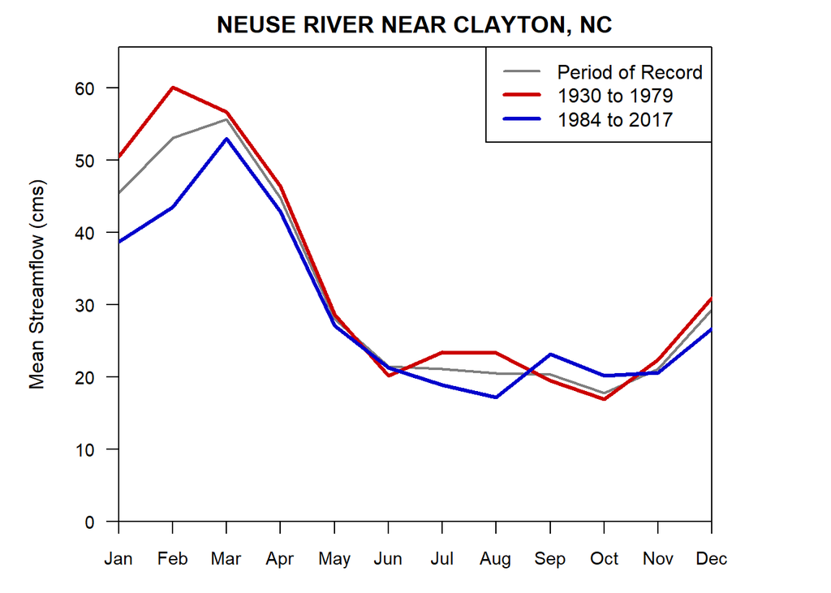

```r
#Reorder from water year to calendar year
month.flow <- arrange(month.flow,Month) #automatically sorts ascending. If want to descend: arrange(month.flow,desc(Month))

#Plot results
par(mar = c(3,5,2,5)) #set plot margins
plot(month.flow$Month, month.flow$p1930to2017, type='n', yaxt="n", xaxt="n", ylim=c(0,max(month.flow$p1930to2017)+10),
     ylab="Mean Streamflow (cms)", xlab = '', main=siteInfo$station_nm,
     yaxs="i", xaxs="i")#gets rid of spaces inside plot
  axis(2, las=2, cex.axis=0.9)   #adds y-axis
  axis(1, at=seq(1,12,1), labels=c("Jan","Feb","Mar","Apr","May","Jun","Jul","Aug","Sep","Oct","Nov","Dec"), cex.axis=0.9); #adds x-axis
#plot monthly lines
  lines(month.flow$Month, month.flow$p1930to2017, col=rgb(0,0,0,0.5), lty=1, lwd=2)
  lines(month.flow$Month, month.flow$p1930to1980, col=rgb(0.8,0,0,1), lty=1, lwd=3)
  lines(month.flow$Month, month.flow$p1984to2017, col=rgb(0,0,0.8,1), lty=1, lwd=3)
#add legend
legend("topright",c("Period of Record", "1930 to 1979", "1984 to 2017"), col=c(rgb(0,0,0,0.5), rgb(0.8,0,0,1), rgb(0,0,0.8,1)), lwd=c(2,3,3))
```

# Exercise 4: Plot monthly streamflow for 1980-1984

1. Use pipes to calculate the monthly streamflow from 1980-1984
2. Add the 1980-1984 line onto the plot

## Load multiple sites for analysis and plot on Leaflet

Let’s say you want to know where all stream gauges are in North Carolina. You can use the USGS NWIS website or you can plot the sites in R. Here, we call on all site data in North Carolina and use `leaflet()` to map sites.

```r
#What sites are available in NC?
nc.sites <- readNWISdata(stateCd="NC", parameterCd = pcode, service = "site", seriesCatalogOutput=TRUE)
length(unique(nc.sites$site_no)) #number of sites in NC
```

```
## [1] 732
```

```r
#filter data
nc.sites2 <- filter(nc.sites, parm_cd %in% pcode) %>%        #with this data if have discharge
             filter(stat_cd %in% scode) %>%                  #for mean daily day
             filter(begin_date <= "1950_01_01") %>%  filter(end_date >= "2010_01_01") %>%  #with data in these years
             mutate(period = as.Date(end_date) - as.Date(begin_date)) %>%  # how many days of data are collected?
             filter(period > 30*365)         #only keep sites with 30+ years of data
length(unique(nc.sites2$site_no))
```

```
## [1] 67
```

```r
#where are sites located?
leaflet(data=nc.sites2) %>%                                    #on this data
  addProviderTiles("CartoDB.Positron") %>%                     #add this map background (can change)
  addCircleMarkers(~dec_long_va,~dec_lat_va,                   #add circle markers based on lat/long
                   color = "red", radius=3, stroke=FALSE,      #with these attributes
                   fillOpacity = 0.8, opacity = 0.8,
                   popup=~station_nm)                         #include in your popup
```

[interactive chart not shown]

# Exercise 5: Load in sites for another state

1. Load in sites for another state and change the name of the variable the data are being saved to
2. Plot the data on leaflet

```r
#let's focus on the upper Neuse upstream of Falls Lake
upper.neuse <- subset(nc.sites2, huc_cd=="03020201")
unique.sites <- unique(upper.neuse$site_no); length(unique.sites)   #how many unique sites are there?
```

```
## [1] 6
```

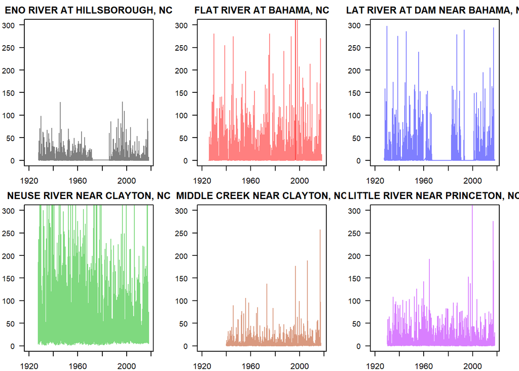

```r
#Load in and plot data
#let's plot all the site data on the same graph to compare.
par(mfrow=c(2,3))    #there are 6 sites so create a matrix with 2 rows and 3 columns
par(mar = c(2,2.5,2,2)) #set plot margins (bottom, left, top, right)
#set up the color for each plot
stream.col <- c(rgb(0,0,0,0.5),rgb(1,0,0,0.5),rgb(0,0,1,0.5),rgb(0,0.7,0,0.5),rgb(0.7,0.2,0,0.5), rgb(0.7,0,1,0.5))
#provide the name of each station
legend.names <- upper.neuse[1:6,]$station_nm

#set up a for loop to read in and plot streamflow over time
for (i in 1:length(unique.sites)){
  #read in the site data
  zt <- readNWISdv(siteNumbers = unique.sites[i], parameterCd = pcode, statCd = scode)
  zt <- renameNWISColumns(zt);
  zt$Flow_cms <- zt$Flow*0.028316847

  #plot the data
  plot(neuse$Date, neuse$Flow_cms, type='n', yaxt="n", xlim=c(as.Date("1920-01-01"),as.Date("2017-12-31")), ylim=c(0,300),
       ylab="Streamflow (cms)", xlab = '', main=legend.names[i])
  axis(2, las=2, cex.axis=0.9)
  lines(zt$Date,zt$Flow_cms,col=stream.col[i])
  #print(legend.names[i])
  } #end for loop
```

```r
dev.off()#turns off plot
```